# Global Refugee Crisis

Author

Khushboo Pursnani

```python
import plotly.express as px
```

```python
!pip install geopandas plotly openpyxl
```

```python
import plotly.express as px
import plotly.io as pio

pio.renderers.default = 'iframe_connected'
```

# Introduction

In contrast, many high-income nations, despite their economic strength, host far fewer refugees, both in absolute terms and relative to population. This raises critical concerns about global equity, shared responsibility, and the disproportionate impact of displacement on already vulnerable regions.

This report also explores whether wealthier countries are stepping up to the crisis. The data reveals a consistent pattern: displacement does not follow economic power. Many of the world’s largest refugee-hosting countries are among the least wealthy. While countries like Jordan and Iran continue to play a key role, many affluent nations contribute significantly less per capita, raising questions of fairness in the global refugee response.

Displacement is rising but global responsibility remains uneven. As conflict, climate, and inequality continue to drive forced migration, the world must do more to share the weight.

```python
# Import necessary libraries
import pandas as pd
from plotnine import *
import plotly.express as px
```

```python
from google.colab import drive
drive.mount("/content/drive")
```

```python
import pandas as pd
from google.colab import drive

# Mount Google Drive (in case it's not already mounted)
drive.mount("/content/drive")

# Double-check this file path for typos!
file_path = '/content/drive/MyDrive/Colab Notebooks/UNICEF_Regional_Metadata_Merged_Final.xlsx'

# Verify the file exists at this path in your Google Drive

df = pd.read_excel(file_path, engine='openpyxl')

df.head()
```

|  | country | alpha_2_code | alpha_3_code | numeric_code | indicator | time_period | obs_value | sex | unit_multiplier | unit_of_measure | ... | inflation_consumer_prices_annual | life_expectancy_at_birth_total_years | military_expenditure_of_gdp | fossil_fuel_energy_consumption_of_total | gdp_growth_annual | birth_rate_crude_per_1_000_people | hospital_beds_per_1_000_people | un_sub_region | world_bank_income_groups_combined | population_total |
| --- | --- | --- | --- | --- | --- | --- | --- | --- | --- | --- | --- | --- | --- | --- | --- | --- | --- | --- | --- | --- | --- |
| 0 | Afghanistan | AF | AFG | 4 | Refugees by host country, per 1 USD GNI per ca... | 2003 | 0 | Total | NaN | per 1 USD GNI per capita | ... | NaN | 57.344 | NaN | NaN | 8.832278 | 47.350 | 0.39 | Southern Asia | Low Income | 22733049.0 |
| 1 | Afghanistan | AF | AFG | 4 | Refugees by host country, per 1 USD GNI per ca... | 2004 | 0 | Total | NaN | per 1 USD GNI per capita | ... | NaN | 57.944 | 2.431254 | NaN | 1.414118 | 46.330 | 0.39 | Southern Asia | Low Income | 23560654.0 |
| 2 | Afghanistan | AF | AFG | 4 | Refugees by host country, per 1 USD GNI per ca... | 2005 | 0 | Total | NaN | per 1 USD GNI per capita | ... | 12.686269 | 58.361 | 1.992066 | NaN | 11.229715 | 45.263 | 0.42 | Southern Asia | Low Income | 24404567.0 |
| 3 | Afghanistan | AF | AFG | 4 | Refugees by host country, per 1 USD GNI per ca... | 2006 | 0 | Total | NaN | per 1 USD GNI per capita | ... | 6.784597 | 58.684 | 1.896234 | NaN | 5.357403 | 44.721 | 0.42 | Southern Asia | Low Income | 25424094.0 |
| 4 | Afghanistan | AF | AFG | 4 | Refugees by host country, per 1 USD GNI per ca... | 2007 | 0 | Total | NaN | per 1 USD GNI per capita | ... | 8.680571 | 59.111 | 2.566267 | NaN | 13.826320 | 43.858 | 0.42 | Southern Asia | Low Income | 25909852.0 |

5 rows × 24 columns

# Data Analysis

The following sections explore refugee trends using various visualizations. Each chart is followed by a brief commentary interpreting the key insights.

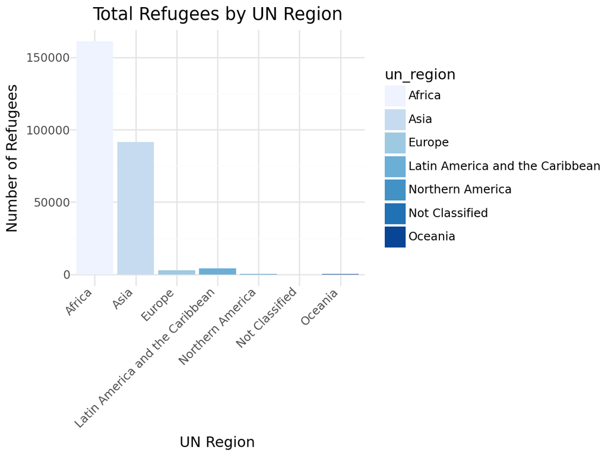

```python
# Summarize total refugees by UN region
bar_data = (
    df.groupby('un_region')['obs_value']
    .sum()
    .reset_index()
    .rename(columns={'obs_value': 'Total_Refugees'})
)

# Plot bar chart
(ggplot(bar_data, aes(x='un_region', y='Total_Refugees', fill='un_region')) +
 geom_bar(stat='identity') +
 scale_fill_brewer(type='seq', palette='Blues') +
 labs(title="Total Refugees by UN Region",
      x="UN Region",
      y="Number of Refugees") +
 theme_minimal() +
 theme(axis_text_x=element_text(angle=45, hjust=1)))
```

## Chart 1: Total Refugees by UN Region

**Key Points:** - **Africa** hosts the highest number of refugees, driven by crises in the Sahel, Horn of Africa, and Central Africa. - **Asia** follows, primarily due to displacement from Afghanistan, Myanmar, and Syria. - **Europe and Latin America** manage moderate refugee numbers, concentrated in a few frontline countries. - **Northern America and Oceania** host relatively few refugees compared to other regions.

> *Africa and Asia’s overwhelming share highlights the urgent need for stronger international support and funding.*

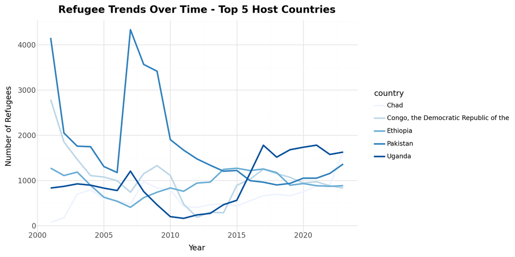

```python
from plotnine import (
    ggplot, aes, geom_line,
    scale_color_brewer, labs, theme_minimal, theme, element_text
)

# pick top 5 host countries
top_countries = (
    df.groupby('country')['obs_value']
      .sum()
      .nlargest(5)
      .index
)
line_data = df[df['country'].isin(top_countries)]

(
    ggplot(line_data, aes('time_period', 'obs_value', color='country')) +
    geom_line(size=1.2) +
    # use a sequential "Blues" palette (light→dark blues)
    scale_color_brewer(type='seq', palette='Blues') +
    labs(
        title="Refugee Trends Over Time - Top 5 Host Countries",
        x="Year", y="Number of Refugees"
    ) +
    theme_minimal() +
    theme(
        axis_text_x=element_text(size=10),
        axis_text_y=element_text(size=10),
        plot_title=element_text(size=14, weight='bold', ha='center'),
        figure_size=(10, 5)
    )
)
```

## Chart 2: Refugee Trends Over Time – Top 5 Host Countries

Trends in refugee hosting show significant fluctuations over the past two decades.

> *These shifts highlight how refugee trends are closely tied to political stability, conflict dynamics, and host country policies.*

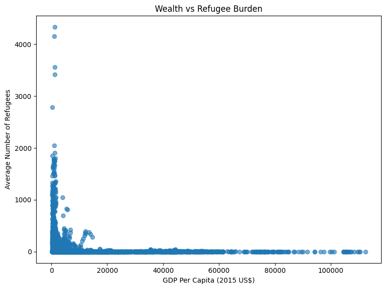

```python
import matplotlib.pyplot as plt

# 1. Prepare your x/y series
x = df['gdp_per_capita_constant_2015_us']
y = df['obs_value']

# 2. Plot
plt.figure(figsize=(8,6))
plt.scatter(x, y, alpha=0.6)

# 3. Labels & title
plt.title('Wealth vs Refugee Burden')
plt.xlabel('GDP Per Capita (2015 US$)')
plt.ylabel('Average Number of Refugees')

plt.tight_layout()
plt.show()
```

## Chart 3: Wealth vs. Refugees Hosted

We observe that low- and middle-income countries tend to host disproportionately higher numbers of refugees compared to wealthier nations.

- **Low-income countries** carry the largest refugee hosting responsibilities despite limited economic resources.
- **Middle-income countries** show varied hosting capacities depending on regional conflicts and proximity.
- **High-income countries** typically host fewer refugees, highlighting a disparity in global responsibility.

> *The data emphasizes a profound imbalance between economic capacity and refugee-hosting obligations worldwide.*

```python
# First, create a new column for refugees per population (%)

df['refugees_per_population_%'] = (df['obs_value'] / df['population_total']) * 100
```

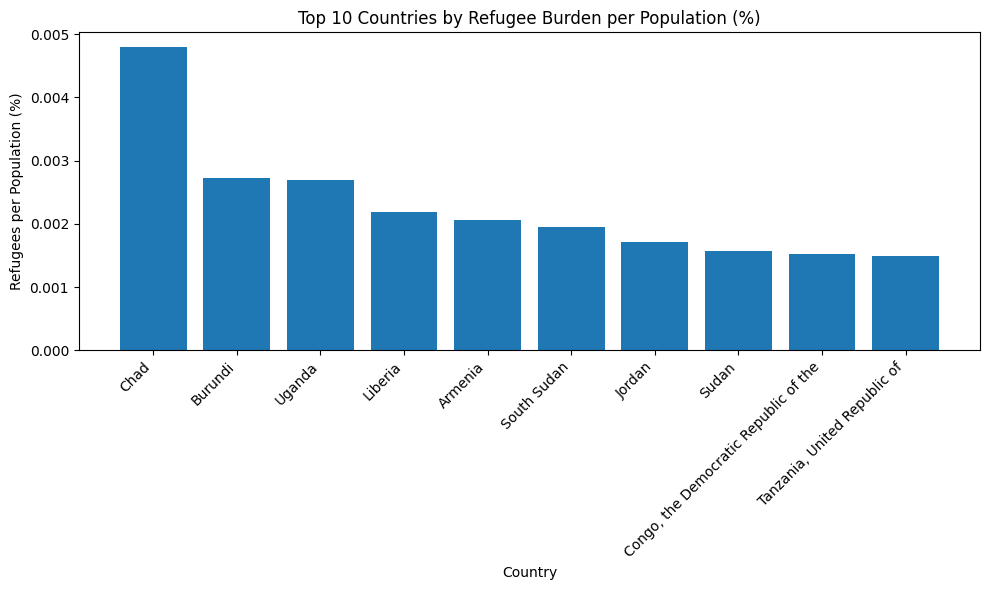

```python
import matplotlib.pyplot as plt

# 1. Aggregate refugees‐per‐pop by country, then pick top 10
pop = (
    df[['country', 'refugees_per_population_%']]
    .dropna()
    .groupby('country')
    .mean()
    .sort_values('refugees_per_population_%', ascending=False)
    .head(10)
)

# 2. Plot
plt.figure(figsize=(10,6))
plt.bar(pop.index, pop['refugees_per_population_%'])

# 3. Labels & title
plt.title('Top 10 Countries by Refugee Burden per Population (%)')
plt.xlabel('Country')
plt.ylabel('Refugees per Population (%)')
plt.xticks(rotation=45, ha='right')

plt.tight_layout()
plt.show()
```

## Chart 4: Global Refugee Burden Relative to Population

- **Chad** hosts the largest burden proportionally, followed by **Burundi** and **Uganda**.
- **Liberia**, **Armenia**, and **South Sudan** also demonstrate significant strain relative to their national populations.
- These figures highlight how smaller and economically vulnerable countries are disproportionately affected.

> *The urgent need for international solidarity and aid becomes clear when considering refugee burdens relative to national population size.*

# Conclusion

The analysis reveals that refugee hosting is disproportionately carried by low- and middle-income countries, despite limited resources.  
Wealthier countries, although financially capable, contribute less proportionately.  
Addressing this imbalance requires collaborative international efforts to distribute humanitarian responsibilities more equitably.

The visualizations highlight regional disparities, emphasizing the need for strategic, long-term solutions to the refugee crisis.